# Introduction

The term Support Vector Machines (SVM's) is sometimes used loosely to refer to three methods, each an extension of the previous method<sup>1</sup>:

- Maximal margin classifier,
- Support vector classifier,
- Support vector machine.

SVM's are a common supervised discriminative algorithm, well suited to *complex* small- to medium sized datasets<sup>2</sup>

They can be used for both **classification** and regression.

## Dataset Example

To demonstrate SVM's I'll be using Fisher's (or Anderson's) Iris flowers dataset<sup>3</sup>.

The dataset consists of 50 samples each from three species of Iris (Iris setosa, Iris virginica and Iris versicolor).

```
Figure 1: Iris Flowers
```

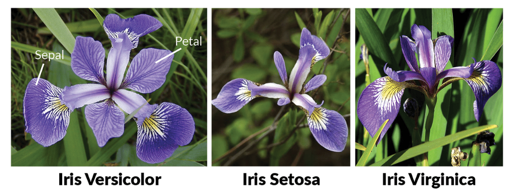

```python
print("Figure 1: Iris Flowers")
display(Image("1_2b9TA6i27eGjeDQE9qUaEg.png")) # Image from:
```

Five attributes were collected for the 150 records:

- sepal length (cm)
- sepal width (cm)
- petal length (cm)
- petal width (cm)
- species

```
Figure 2: Iris Attributes
```

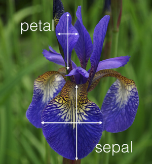

[output not shown]

```python
print("Figure 2: Iris Attributes")
display(Image("03_iris.png"))       # Image from: https://www.ritchieng.com/machine-learning-iris-dataset/
```

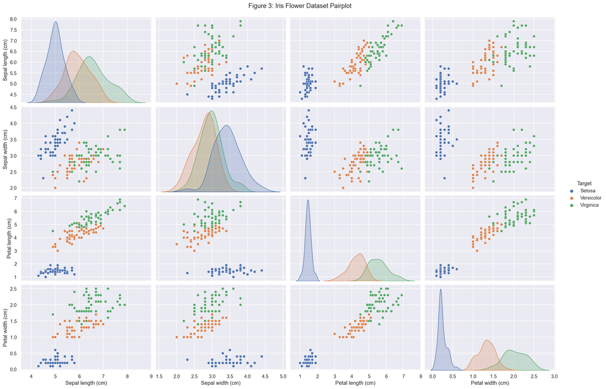

```python
sns.pairplot(iris_vis, hue="Target", height=3, aspect = 1.5)
plt.suptitle("Figure 3: Iris Flower Dataset Pairplot", y=1.02)
plt.show()
```

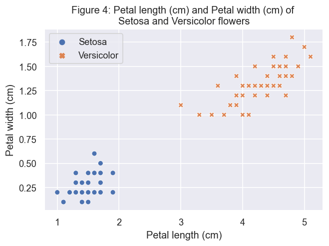

```python
reduced_plot(iris_reduced, X_AX_LABEL, Y_AX_LABEL, title4)
plt.show()
```

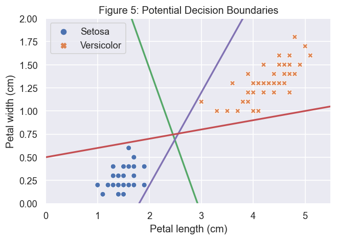

```python
example_lines(iris_reduced, X_AX_LABEL, Y_AX_LABEL, title5,
              [pred_1, pred_2, pred_3])
```

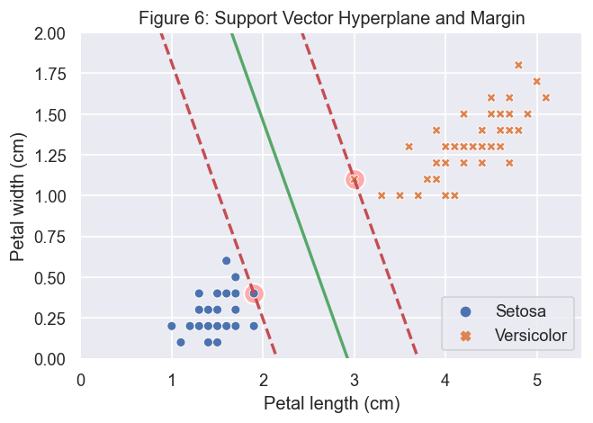

```python
svc_decision_boundary(svm_clf)
reduced_plot(iris_reduced, X_AX_LABEL, Y_AX_LABEL, title6)
plt.show()
```

# What is a Hyperplane?

In $p$-dimensional space, a hyperplane is a flat affine subspace of dimension $p-1$.

**Examples**

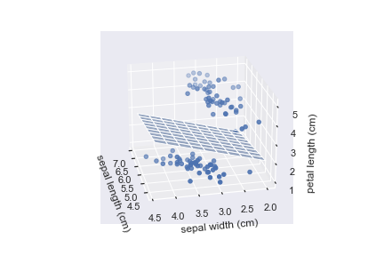

```python
three_dim()
```

In more detail<sup>1</sup>:

*Two-dimensions*: $\beta_0 + \beta_1X_1 + \beta_2X_2 = 0$

*Three-dimensions*: $\beta_0 + \beta_1X_1 + \beta_2X_2 + \beta_3X_3 = 0$

*P-dimensions*: $\beta_0 + \beta_1X_1 + \beta_2X_2 + ... + \beta_pX_p = 0$

If $X = (X_1, ..., X_p)^T$ satisfies above, then it is a point on the hyperplane.

If $\beta_0 + \beta_1X_1 + \beta_2X_2 + ... + \beta_pX_p > 0$, it lies on one side of the hyperplane,

so if, $\beta_0 + \beta_1X_1 + \beta_2X_2 + ... + \beta_pX_p < 0$, its on the other side.

### Classifying data

We aim to classify an $n \times p$ matrix of $n$ observations in $p$ dimensional space, with these observations falling into two classes $y_1,...,y_n \in \{-1,1\}$.

If we were to perfectly separate the classes the hyperplane would have the property that

$\beta_0 + \beta_1X_{i1} + \beta_2X_{i2} + ... + \beta_pX_{ip} > 0$ if $y_i = 1$,

$\beta_0 + \beta_1X_{i1} + \beta_2X_{i2} + ... + \beta_pX_{ip} < 0$ if $y_i = -1$.

For a new test observations $x^*$, we would look at the sign of:

$f(x^*) = \beta_0 + \beta_1x_1^* + \beta_2x_2^* + ... + \beta_px_p^*$.

We would assign it to class 1 if $f(x^*)$ is positive and class -1 if negative.

Furthermore, we could use the magnitude of $f(x^*)$ to indicate how far the point lies from the hyperplane.